# Hydrogen-bonded Ionic Liquids (SRS-MP2)

The raw geometries of 42 hydrogen-bonded ionic liquids were constructed and then geometry optimised using Truhlar’s M06-2X functional along with aug-cc-pVDZ in ethanol. Then CCSD(T)/aVDZ and MP2/(aug)-cc-pVXZ calculations, where X = D,T,Q, were run.

And the number of high and low ratios by basis set, as well as the distributions (note the low number $\epsilon_{\Delta s} < 1$ systems):

```r
hbil.mp2_spin <- hbil_mp2[Component == "nonCP", !c("Method", "RefEn"), with = FALSE]

hbil.mp2_spin <- merge(hbil.mp2_spin, hbil.ccsdt_cbs[Basis == "cbs", !c("OS", "SS", "RefEn", "Basis", "Total"), with = F]
                  , by = c("Suite", "System"))

hbil.mp2_spin[, eps := OS / SS]
hbil.mp2_spin[, r := as.factor(ifelse(eps > 1, "A", "B"))]

print(hbil.mp2_spin[, nrow(.SD), by = .(r, Basis)])
```

```
##     r Basis V1
##  1: A   adz 38
##  2: A   aqz 30
##  3: A   atz 40
##  4: A    dz 40
##  5: A    qz 29
##  6: A    tz 39
##  7: B   aqz 12
##  8: B    qz 13
##  9: B   adz  4
## 10: B    tz  3
## 11: B   atz  2
## 12: B    dz  2
```

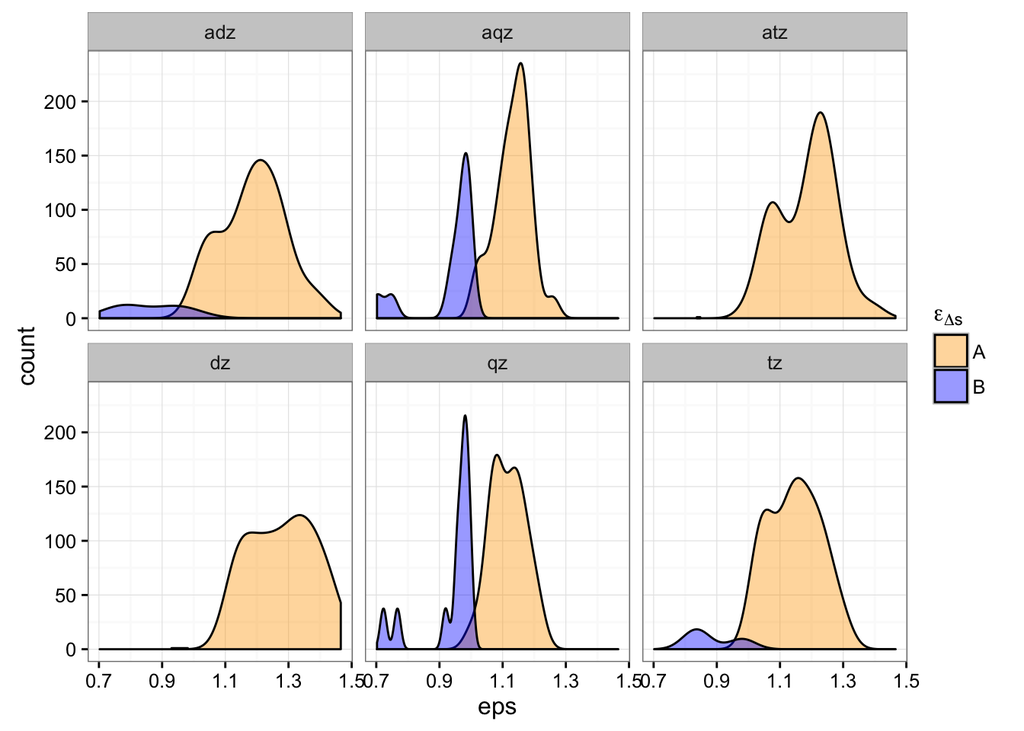

```r
ggplot(hbil.mp2_spin, aes(x = eps, y = ..count..)) +
    #geom_freqpoly(binwidth = 0.005, aes(colour = Basis, linetype = r)) #+
    geom_density(aes(fill = r), alpha = 0.4) +
    theme_bw() +
    facet_wrap(~ Basis) +
    scale_fill_manual(name = bquote(epsilon[Delta*s]), values = c("orange", "blue"))
```

The procedure followed is pretty much identical to that of the stacked base pairs, so very briefly:

1. Helgaker extrapolation, using correction term assuming basis set indifference between MP2 and CCSD(T) to obtain CCSD(T)/CBS.
2. All energies used for the benchmark energies were counterpoise corrected.
3. **Non-counterpoise corrected** energies used for SRS-MP2, the coefficients are displayed in the code below.

```r
paramA <- data.table(r = as.factor("A")
                    , Basis = c("dz", "tz", "qz", "adz", "atz", "aqz")
                    , c.OS = 0
                    , c.SS = c(1.752, 1.640, 1.689, 1.372, 1.443, 1.591))

paramB <- data.table(r = as.factor("B")
                    , Basis = c("dz", "tz", "qz", "adz", "atz", "aqz")
                    , c.OS = c(0.543, 0.660, 0.671, 0.856, 0.635, 0.699)
                    , c.SS = c(1.518, 1.140, 1.119, 1.033, 1.047, 1.075))

params_SRS.1 <- rbind(paramA, paramB)

# merge
hbil.srs.dt <- merge(hbil.mp2_spin, params_SRS.1, by = c("Basis", "r"))


hbil.srs.dt[, srs.1 := c.OS * OS + c.SS * SS]
```

And the errors, by basis set:

```r
print(hbil.srs.dt[, as.list(nomed.stats(ccsdt.cbs - srs.1)), by = .(Basis)])
```

```
##    Basis      MAE       SD        Min       Max
## 1:   adz 8.752018 3.415165 -12.845411  2.998505
## 2:   aqz 4.576857 2.756254  -8.152408  1.495368
## 3:   atz 7.486606 2.435534 -11.174840  1.510554
## 4:    dz 3.326660 4.021960  -8.907997 11.420101
## 5:    qz 2.227345 2.258830  -4.283785  3.716149
## 6:    tz 2.224755 2.447609  -5.198028  6.051851
```

And the largest errors for SRS-MP2:

```r
hbil.srs.dt[abs(ccsdt.cbs - srs.1) > 3 & Basis == "tz"]
```

```
##     Basis r Suite            System Component        OS        SS    CorrEn      d_mp2 ccsdt.cbs       eps c.OS c.SS     srs.1
##  1:    tz A  hbil EtMeNH2-CF3SO3-p1     nonCP -24.85911 -20.99670 -30.41427  0.1960809 -37.53663 1.1839531 0.00 1.64 -34.43459
##  2:    tz A  hbil       EtNH3-Cl-p1     nonCP -22.59371 -18.20779 -23.94447  2.2208974 -32.91470 1.2408814 0.00 1.64 -29.86077
##  3:    tz A  hbil    TMEA-CF3SO3-p1     nonCP -21.69979 -17.60627 -27.46470 -0.2790428 -32.41557 1.2325031 0.00 1.64 -28.87429
##  4:    tz A  hbil        TMEA-Cl-p1     nonCP -17.64796 -14.85441 -21.74678  0.7377518 -28.31055 1.1880616 0.00 1.64 -24.36124
##  5:    tz A  hbil       TMEA-TFA-p1     nonCP -21.15107 -17.89191 -27.23387 -0.4915807 -32.92164 1.1821579 0.00 1.64 -29.34274
##  6:    tz A  hbil     TMEA-mOSO3-p1     nonCP -20.78163 -17.56413 -26.19685 -0.3259558 -32.65905 1.1831858 0.00 1.64 -28.80518
##  7:    tz A  hbil     mim-CF3SO3-p1     nonCP -17.52946 -15.23863 -23.06095 -1.8242929 -28.74053 1.1503301 0.00 1.64 -24.99136
##  8:    tz A  hbil        mim-NO3-p2     nonCP -29.55903 -22.86908 -36.44960  2.8481029 -42.70332 1.2925322 0.00 1.64 -37.50530
##  9:    tz A  hbil      mim-mOSO3-p1     nonCP -17.17843 -16.27249 -22.77115 -1.2614990 -29.82373 1.0556733 0.00 1.64 -26.68688
## 10:    tz B  hbil     mim-CF3SO3-p2     nonCP -15.83793 -16.15053 -18.70900  0.4475030 -24.89063 0.9806443 0.66 1.14 -28.86464
## 11:    tz B  hbil       mim-mSO3-p1     nonCP -14.46620 -17.53789 -14.34067  1.3276451 -23.48903 0.8248539 0.66 1.14 -29.54089
```

```r
hbil.srs.dt[abs(ccsdt.cbs - srs.1) > 3 & Basis == "qz"]
```

```
##     Basis r Suite            System Component        OS        SS    CorrEn      d_mp2 ccsdt.cbs       eps  c.OS  c.SS     srs.1
##  1:    qz A  hbil EtMeNH2-CF3SO3-p1     nonCP -22.43071 -19.97788 -30.41427  0.1960809 -37.53663 1.1227772 0.000 1.689 -33.74263
##  2:    qz A  hbil    TMEA-CF3SO3-p1     nonCP -19.75847 -16.65588 -27.46470 -0.2790428 -32.41557 1.1862757 0.000 1.689 -28.13179
##  3:    qz A  hbil       TMEA-TFA-p1     nonCP -19.27615 -17.27596 -27.23387 -0.4915807 -32.92164 1.1157786 0.000 1.689 -29.17910
##  4:    qz A  hbil     TMEA-mOSO3-p1     nonCP -19.25686 -16.86942 -26.19685 -0.3259558 -32.65905 1.1415248 0.000 1.689 -28.49245
##  5:    qz A  hbil     mim-CF3SO3-p1     nonCP -15.71655 -14.62929 -23.06095 -1.8242929 -28.74053 1.0743211 0.000 1.689 -24.70887
##  6:    qz A  hbil        mim-NO3-p2     nonCP -27.56523 -22.84756 -36.44960  2.8481029 -42.70332 1.2064846 0.000 1.689 -38.58953
##  7:    qz B  hbil       DMEA-TFA-p1     nonCP -22.16753 -22.60677 -28.80507  1.3473793 -37.08815 0.9805703 0.671 1.119 -40.17139
##  8:    qz B  hbil      DMEA-mSO3-p1     nonCP -21.11613 -22.12872 -26.85574  1.8120297 -35.76265 0.9542408 0.671 1.119 -38.93096
##  9:    qz B  hbil       mim-mSO3-p1     nonCP -12.77292 -16.65286 -14.34067  1.3276451 -23.48903 0.7670103 0.671 1.119 -27.20518
## 10:    qz B  hbil      mpyr-mSO3-p1     nonCP -25.30598 -25.91853 -33.09859  2.4855439 -42.66563 0.9763665 0.671 1.119 -45.98314
```

This isn’t very encouraging. What if we fit new coefficients to the 42 HBILs, and see how they perform?

```r
hbil.srs.dt[, coef.simple.fn(.SD, x = "ccsdt.cbs", y = c("OS", "SS", "0")), by = .(Basis)] %>% print()
```

```
##    Basis        OS        SS      R.sq       MAE        Med       SD       Min      Max  n
## 1:   adz 0.5590860 1.2192060 0.9972295 1.4554320 -0.4739056 1.793153 -3.574205 3.635298 42
## 2:   aqz 0.8597523 0.9419270 0.9986248 1.0353370 -0.3580203 1.263701 -2.866606 2.711035 42
## 3:   atz 0.8862052 0.8142564 0.9988579 0.9795642 -0.2789152 1.151356 -2.422564 1.899591 42
## 4:    dz 0.7167963 0.8816213 0.9902174 2.8693622 -0.9118188 3.369011 -5.878940 6.754469 42
## 5:    qz 0.7095632 0.9987244 0.9980200 1.3056389 -0.2777456 1.521001 -2.978011 2.945817 42
## 6:    tz 0.6802021 0.9115023 0.9968488 1.5988585 -0.3827727 1.918214 -3.306514 3.995235 42
```

Here, we did not separate by ratio, as in SRS-MP2, because for most basis sets, the majority of systems have $\epsilon_{\Delta s} > 1$. But what if we did separate by ratio?

```r
hbil.srs.dt[r == "A", coef.simple.fn(.SD, x = "ccsdt.cbs", y = c("OS", "0")), by = .(Basis)]
```

```
##    Basis       OS      R.sq      MAE        Med       SD       Min      Max  n
## 1:   adz 1.579025 0.9949674 2.065174 -0.5735712 2.493859 -4.873317 4.430452 38
## 2:   aqz 1.690879 0.9985315 1.082989 -0.2135135 1.371107 -3.129014 2.698014 30
## 3:   atz 1.570332 0.9980478 1.252672 -0.3289144 1.532939 -3.146840 2.695870 40
## 4:    dz 1.403436 0.9881972 3.066477 -1.7219948 3.747594 -6.824298 7.329174 40
## 5:    qz 1.603732 0.9969603 1.784952 -0.8241754 1.978704 -3.535383 3.157525 29
## 6:    tz 1.472780 0.9949181 1.989436 -0.5302107 2.484229 -4.523677 5.060549 39
```

```r
hbil.srs.dt[r == "B", coef.simple.fn(.SD, x = "ccsdt.cbs", y = c("OS", "SS", "0")), by = .(Basis)]
```

```
##    Basis         OS          SS      R.sq       MAE        Med        SD       Min       Max  n
## 1:   adz  1.4611339   0.4634930 0.9920808 1.8414706 -0.5299040 2.1454135 -2.710309 1.4574227  4
## 2:   aqz  0.8527553   0.9556001 0.9978069 1.1988860 -0.2401157 1.4514319 -2.798681 1.5782609 12
## 3:   atz 35.7662579 -28.4423674 1.0000000 0.0000000  0.0000000 0.0000000  0.000000 0.0000000  2
## 4:    dz  3.2153357  -1.6282284 1.0000000 0.0000000  0.0000000 0.0000000  0.000000 0.0000000  2
## 5:    qz  1.0146487   0.7006199 0.9976266 1.2831620  0.1685835 1.5165327 -2.616935 1.3576598 13
## 6:    tz  1.1404248   0.4288432 0.9989196 0.5762527  0.0973805 0.8452039 -1.101798 0.5295801  3
```

So…large errors still for “A” systems, which is where the majority of ion pairs lie. “B” systems have a much smaller number, so correspondingly smaller errors. Ignoring the double-$\zeta$ basis sets, cc-pVTZ has the largest max errors…and MAE…and SD. Not very encouraging :(

### Comparing CP corrected MP2 against CCSD(T)/CBS

```r
hbil.mp2_cp <- merge(hbil.mp2_cbs
                     , hbil.ccsdt_cbs[, c("Suite", "System", "ccsdt.cbs"), with = F]
                     , by = c("Suite", "System"))
hbil.mp2_cp[, as.list(nomed.stats(ccsdt.cbs - OS - SS)), by = .(Basis)] %>% print()
```

```
##    Basis      MAE       SD        Min       Max
## 1:   adz 6.651300 1.536326  -9.605202 -3.405624
## 2:   aqz 1.140407 1.487467  -4.205074  2.846993
## 3:   atz 1.826041 1.407006  -5.254068  1.243153
## 4:    dz 9.957552 3.747539 -17.962274 -2.509151
## 5:    qz 1.505630 1.957929  -4.000741  4.255156
## 6:    tz 2.610960 2.453128  -7.494378  3.143841
## 7:   cbs 1.440973 1.587127  -3.439591  4.017363
```

Looks like aug-cc-pVQZ is the best, even better than MP2/CBS.